# STA2016 Final Project: Mapping Mississauga’s Groundwater

Markus Kangur

December 21 2024

## Introduction

Understanding how the water table varies spatially is important to organizations like conservation authorities and municipal governments because of the potential impacts of high groundwater levels on the built and natural environment. Urban development, especially buildings with deep foundations or basements, can be at risk of needing expensive restoration work due to groundwater-driven flooding and damage. However, groundwater levels are not readily observable, requiring costly well or borehole installation to take measurements. Fortunately, geostatistical data consisting of archived well records can be utilized to generate a surface of estimated depth to groundwater across a study area.

In this study, we are interested in estimating the depth to groundwater throughout the City of Mississauga. While the Oak Ridges Moraine Groundwater Program (ORMGP) has previously considered this problem for much of Southern Ontario, few details about their statistical methodology is available. No uncertainty quantification is available, and the analysis was conducted using the default settings in Surfer, a mapping software package. In this study, we extend the work of the ORMGP by conducting a detailed kriging analysis to produce a water table surface along with standard error estimates using well record data obtained from the ORGMP. We also apply generalized additive models (GAMs) and compare their predictive performance to kriging through a cross-validation study.

## Methods

**Data Description and Processing**

All data were projected to WGS 84 UTM Zone 17N. To define the study area, a shapefile of the Mississauga municipal boundary was obtained from [Mississauga Open Data](https://data.mississauga.ca/datasets/municipal-boundary/explore?location=43.609202%2C-79.675599%2C11.85). Water table point observations in metres above sea level were extracted from the ORGMP’s [online mapping platform](https://maps.oakridgeswater.ca/Html5Viewer/index.html?viewer=ORMGPP). These observations consist of a combination of static water level measurements taken at the time wells were drilled and average values from monitoring wells. The source data also includes measurements taken at locations where the groundwater table meets surface water features, such as around Lake Ontario. To improve estimation accuracy, we consider all observations within a five kilometre buffer around the City boundary, since the water table does not follow municipal boundaries, so points located near the City should still provide information about the water table within the City. Of the 2062 measurements obtained, 1854 data points with complete location and water table level data at distinct locations were retained.

Across the study area, the water table elevation above sea level has a minimum of 66.02 metres, a mean of 171.11 metres, and a maximum of 241.05 metres. The distribution is reasonably bell-shaped, and applying transformations only increased the skewness. Therefore the untransformed data was utilized. However, this data is not indicative of the groundwater depth below the surface, since the elevation varies significantly over the study area. To address this, a digital elevation model (DEM) covering the Greater Toronto Area at a spatial resolution of five metres was obtained from [Ontario GeoHUB](https://geohub.lio.gov.on.ca/maps/mnrf::greater-toronto-area-gta-digital-elevation-model-2002/about). This data product is a representation of the ground surface elevation in metres above sea level. Since it is distributed in 20 kilometre raster tiles, four raster tiles were merged together, and then cropped and masked to the study area. Finally, the elevation at each well record was extracted from the DEM to compute the depth to groundwater. Figure 1 below shows the elevation across the study area (downscaled to 50m resolution for computational purposes) as well as the depth to groundwater at the point locations.

[interactive chart not shown]

Figure 1: Elevation in metres above sea level (left) and observed depth to groundwater in metres (right) across the study area.

**Statistical Modelling**

To begin the kriging process, we explore the binned empirical semivariogram for the data for different bin numbers and maximum distances. The full empirical semivariogram is irregular with multiple peaks and no obvious sill. Since it would not be well approximated by any particular parametric semivariogram model, we consider a truncated semivariogram with 18 bins and a maximum distance of 23000 metres. Figure 2 shows the full and truncated empirical semivariograms below. Note that the shape of the truncated semivariogram appears much more reasonable to model.

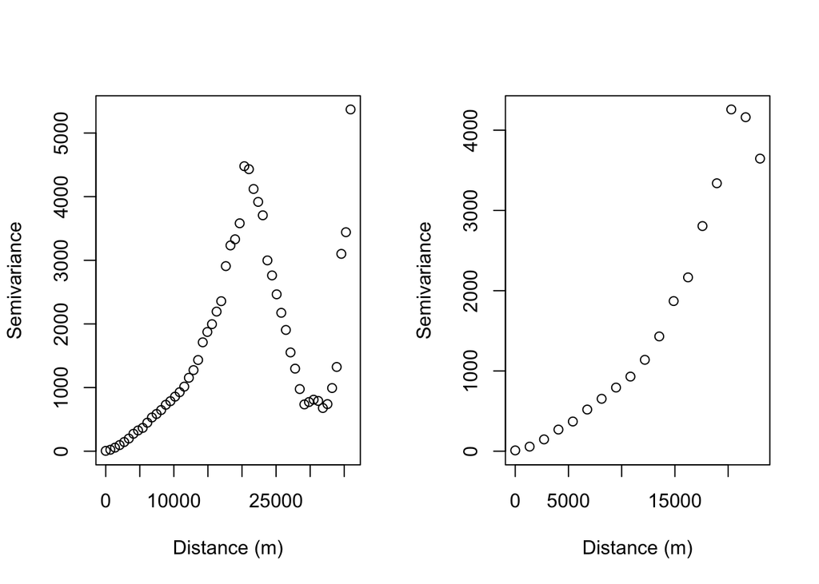

Figure 2: Full (left) and truncated (right) empirical semivariograms

We applied ordinary kriging, which assumes that the underlying process has a constant mean. The semivariogram model with the lowest SSE was used. Kriging provides the best unbiased linear predictor for estimating values at unobserved locations, provided that we are working with a stationary process, meaning that the underlying process is invariant under translation. This assumption along with potential for anisotropy are detailed in the limitations section. We also fit GAMs, which model the spatial component directly in the mean component of the regression model. In this approach, we fit thin plate smoothing splines to the data as a function of the x and y coordinates of the observations. Elevation was not included as a covariate since it resulted in nonsensical output, as the elevation term dominated the predictions. The number of knots controls the bumpiness and level of detail in the fitted surface.

Five-fold cross validation was used to tune the number of knots in the GAM and to evaluate the predictive performance of both the kriging and GAM models. The data were split into five folds of equal size, creating five test sets (each single fold) and training sets (the remaining folds). We fit each model on the training set and then predicted the values at the locations in the test sets, using AIC, MSE, and R-squared to compare the model fits. The five models considered were ordinary kriging, and GAMs with 200, 400, 600 and 800 knots. After choosing the best GAM model, the final kriging and GAM models were trained on all of the data to generate the final water table surfaces by subtracting from the elevation raster. Negative values (incorrectly indicating aboveground water) were corrected to a depth of 0.5 metres below the ground surface. The final surfaces and their respective standard errors were also clipped and masked to the City boundary for display purposes.

## Results

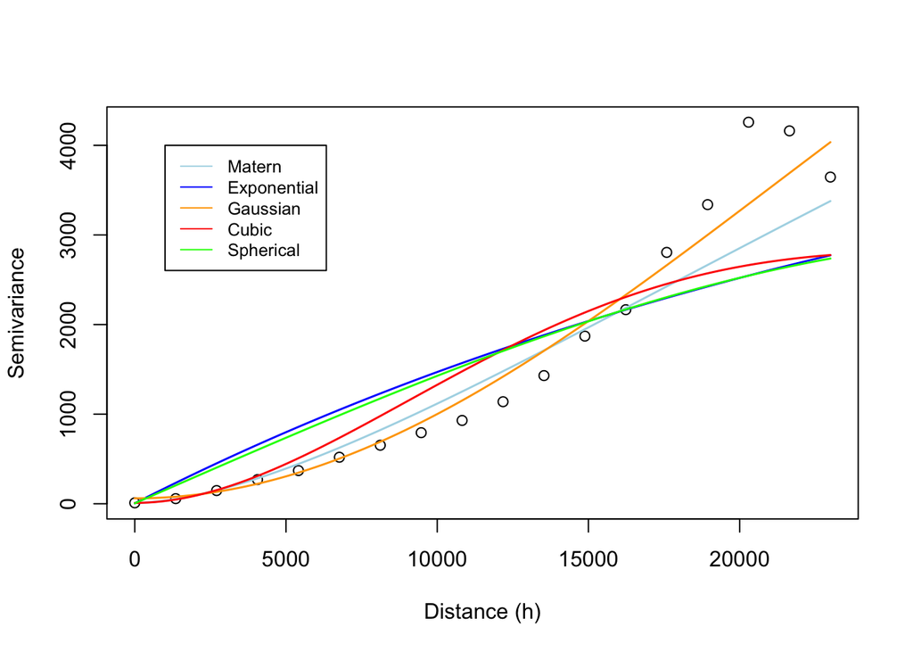

Figure 3: Fitted Theoretical Semivariograms

Figure 3 above shows a plot of the five fitted theoretical semivariograms, while Table 1 below shows their respective estimated parameters and SSEs. From the plot, it appears that either the Gaussian or the Matern models fit the data the best. These models also have the significantly lower SSE values than the other models. We use the Gaussian semivariogram when conducting the following ordinary kriging because it has the lowest SSE.

Table 1: Fitted Semivariogram Properties

| Model | Nugget | Partial Sill | Range | SSE |
| --- | --- | --- | --- | --- |
| Matern | 9.45 | 11401.02 | 30000 | 64163.11 |
| Exponential | 4.66 | 5169.47 | 30000 | 303326.24 |
| Gaussian | 60.27 | 8943.27 | 30000 | 39718.35 |
| Cubic | 9.11 | 2818.07 | 30000 | 142279.69 |
| Spherical | 4.59 | 2954.41 | 30000 | 281390.68 |

The AIC, MSE, and R-squared of each model fit during cross-validation are shown below in Table 2. Ordinary kriging performed far worse than all GAM models, with a slightly lower R-squared and significantly higher MSE than the GAMs. The GAM with 800 knots performed the best, with the lowest AIC, lowest MSE, and highest R-squared of all the models. We generate final surfaces with standard errors for the GAM with 800 knots and the kriging model for comparison.

Table 2: Model Comparison and Diagnostics

| Model | AIC | MSE | R-squared |
| --- | --- | --- | --- |
| Kriging | NA | 89.80 | 0.94 |
| GAM (200 knots) | 8270.10 | 16.35 | 0.99 |
| GAM (400 knots) | 7776.74 | 13.79 | 0.99 |
| GAM (600 knots) | 7373.40 | 15.66 | 0.99 |
| GAM (800 knots) | 7076.85 | 11.67 | 0.99 |

Figure 4 below shows the kriged final depth to groundwater map and its standard errors predicted into a 100m resolution raster. The constant mean of the process was estimated to be 121.71 metres, before adjusting for surface elevation. There is little spatial variation in large portions of the map. The standard errors are quite high and are relatively constant except along the shore of Lake Ontario, which could be due to the fact that no data was available beyond that boundary when kriging.

[interactive chart not shown]

Figure 4: Kriged depth to groundwater surface in metres (left) and the respective standard errors in metres (right).

The GAM-derived groundwater surface and its standard errors are shown below in Figure 5. Both the intercept and the spatial component of the model are highly significant (p < 2e-16). There is much more spatial variation in this map than in the kriging one, with the river systems highly visible throughout the study area. The standard errors are much smaller than the kriging standard errors, and their spatial distribution is much more interesting. There is an area of high uncertainty along the northeast shore of Lake Ontario, as well as another near Pearson Airport. This is expected since there are little to no groundwater observations taken in these areas as shown in Figure 1. Both the kriged and GAM-derived surfaces show an area of very deep groundwater levels near central Mississauga. This is reasonable since it is at the site of a former landfill, where the elevation was increased artificially.

[interactive chart not shown]

Figure 5: GAM-modeled depth to groundwater in metres (left) and the respective standard errors in metres (right)

Since kriging is an exact interpolator, it doesn’t make sense to conduct residual analysis as the predicted values will match the fitted values. However, we can plot an empirical semivariogram of the residuals from the GAM model, as shown below in Figure 6. The semivariance is very low, and is nearly constant for all distance values. This indicates that the GAM model does an excellent job of modelling the spatial component of the process.

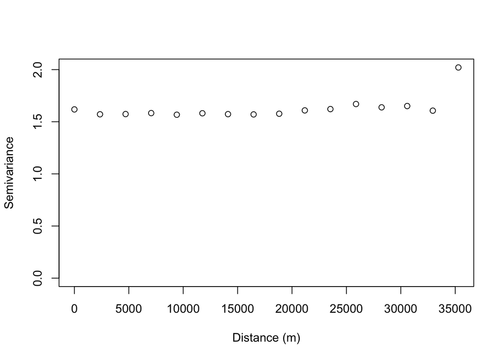

Figure 6: Empirical semivariogram for GAM residuals

## Conclusion

In this study we extended the previous work of the ORMGP by using kriging and GAMs to construct groundwater depth surfaces along with uncertainty estimates for the City of Mississauga. Understanding how the water table varies spatially is important to organizations like conservation authorities and municipal governments because of the potential impacts of high groundwater levels on the built and natural environment. In the cross-validation study, a GAM with 800 knots significantly outperformed the ordinary kriging model with Gaussian semivariogram. The depth to groundwater surface constructed using the GAM has a high level of detail, and conforms well to the surface hydrology of the region. Residual analysis further confirmed that the GAM adequately addresses the spatial variation in groundwater levels. This analysis adds significant value through the addition of uncertainty quantification, which could be used to construct confidence intervals for groundwater depth at any location of interest. However, there were some significant limitations, particularly during kriging, that could be addressed in future work.

## Limitations and Future Work

Since the function that fits theoretical semivariograms via maximum likelihood and REML does not support variogram truncation, it did not make sense to proceed given the highly irregular empirical semivariogram. This limited the variogram fitting methods to least squares or weighted least squares. Importantly, these estimation methods cannot be used to conduct universal kriging in R, which meant that we could not account for any trends in the x or y coordinates. Additionally,the core assumption of stationarity was violated by the anisotropy visible in the directional semivariogram below in Figure 7. In this case, the semivariance depends heavily on direction, with the 0 and 45 degree directions behaving very differently from the 90 and 135 degree directions. Further work could focus on adjusting for this anisotropy. Kriging was also extremely computationally intensive, and the final predicted surfaces had to be reduced from 50 metre to 100 metre resolution because the computer was running out of RAM. Finally, the analysis does not consider additional variables that can influence groundwater levels, such as subsurface geological conditions and surface permeability. Future analysis could incorporate these variables into the GAM models as covariates.

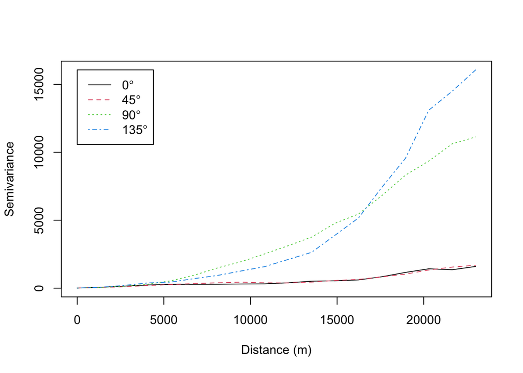

Figure 7: Directional empirical semivariogram